# Risk Prediction Face-Off: Evaluating ANNs Against Logistic Regression for Credit Card risk of Customers

Author : Zeedan Shaikh (Bsc & Msc in Statistics Presidency University,kolkata)

## Introduction

When assessing the risk of credit card default, financial institutions rely on predictive models to make informed decisions about lending. Two prominent methodologies for tackling this problem are Logistic Regression and Artificial Neural Networks (ANNs). Both techniques offer unique advantages and limitations, and choosing between them can significantly impact the accuracy and efficiency of risk prediction.

**Logistic Regression** is a traditional statistical method commonly used for binary classification problems, such as predicting whether a customer will default on a credit card payment. Its simplicity, interpretability, and relatively low computational cost make it a popular choice in the financial sector. Logistic Regression models the probability of default as a function of various customer characteristics, providing insights that are easy to understand and communicate.

In contrast, **Artificial Neural Networks** represent a more complex approach, inspired by the neural processes of the human brain. ANNs are capable of capturing intricate patterns and relationships within the data through their multiple layers and nodes. This capacity for modeling non-linear interactions and handling large datasets can potentially lead to more accurate predictions. However, the trade-offs include higher computational demands and a more opaque decision-making process, which can be challenging for interpretability.

### Motiavtion

Understanding how these models compare in the context of credit card risk prediction is crucial for optimizing decision-making processes in financial services. This comparison not only highlights the strengths and weaknesses of each method but also helps in selecting the most appropriate model based on the specific needs and constraints of the lending institution.

### Objective

- It is very important to observe we cannot really control **What Type of Customer Will Approach the Bank** so here regression aspect of logistic model is meaningless as we cannot change the predictors to get the suitable value of response.
- So we will use **Logistic Regression** for prediction Purpose and also compare it with the results of **ANN**
  - Accuracy comparison
  - F Score comparison
  - ROC Curve visulization

## Methodology

### Data Collection

Dataset Link : [Click Here](https://www.kaggle.com/datasets/samuelcortinhas/credit-card-classification-clean-data)

**Variable Details**

**ID:** A unique identifier for each customer. **Gender:** The gender of the customer (e.g., Male, Female). Categorical variable. **Own_car:** Indicates whether the customer owns a car (e.g., Yes, No). Binary categorical variable. **Own_property:** Indicates whether the customer owns property (e.g., Yes, No). Binary categorical variable. **Work_phone:** Indicates whether the customer has a work phone (e.g., Yes, No). Binary categorical variable. **Phone:** Indicates whether the customer has a personal phone (e.g., Yes, No). Binary categorical variable. **Email:** Indicates whether the customer has an email address (e.g., Yes, No). Binary categorical variable. **Unemployed:** Indicates whether the customer is unemployed (e.g., Yes, No). Binary categorical variable. **Num_children:** The number of children the customer has. Numeric variable. **Num_family:** The number of family members the customer has. Numeric variable. **Account_length:** The length of time the customer has held their account. Numeric variable (often in months or years). **Total_income:** The total income of the customer. Numeric variable. **Age:** The age of the customer. Numeric variable. **Years_employed:** The number of years the customer has been employed. Numeric variable. **Income_type:** The type of income the customer receives (e.g., Salary, Business, Pension). Categorical variable. **Education_type:** The level of education the customer has attained (e.g., High School, Bachelor’s, Master’s). Categorical variable. **Family_status:** The customer’s family status (e.g., Single, Married, Divorced). Categorical variable. **Housing_type:** The type of housing the customer lives in (e.g., Owned, Rented). Categorical variable. **Occupation_type:** The customer’s occupation (e.g., Professional, Clerical, Service). Categorical variable. **Target:** The variable indicating the risk outcome (e.g., Defaulted, Not Defaulted). This is the dependent variable you are predicting.

### Data preprocessing

Getting the required libraries:

```python
import numpy as np
import pandas as pd
import matplotlib.pyplot as plt
import seaborn as sns
from imblearn.over_sampling import SMOTENC
from sklearn.preprocessing import StandardScaler
from IPython.display import display, HTML
#--model
from sklearn.linear_model import LogisticRegression
from sklearn.model_selection import train_test_split
from tensorflow.keras.models import Sequential
from tensorflow.keras.layers import Dense, Dropout
from tensorflow.keras.optimizers import Adam
from tensorflow.keras.callbacks import ReduceLROnPlateau, ModelCheckpoint, EarlyStopping
# Metrices
from sklearn.metrics import accuracy_score , classification_report , precision_score , recall_score , confusion_matrix , f1_score , roc_auc_score , roc_curve
```

Loading the data

```python
credit_data=pd.read_csv("/content/drive/MyDrive/credit_approval/dataset.csv")
credit_data.head()
```

|  | ID | Gender | Own_car | Own_property | Work_phone | Phone | Email | Unemployed | Num_children | Num_family | Account_length | Total_income | Age | Years_employed | Income_type | Education_type | Family_status | Housing_type | Occupation_type | Target |
| --- | --- | --- | --- | --- | --- | --- | --- | --- | --- | --- | --- | --- | --- | --- | --- | --- | --- | --- | --- | --- |
| 0 | 5008804 | 1 | 1 | 1 | 1 | 0 | 0 | 0 | 0 | 2 | 15 | 427500.0 | 32.868574 | 12.435574 | Working | Higher education | Civil marriage | Rented apartment | Other | 1 |
| 1 | 5008806 | 1 | 1 | 1 | 0 | 0 | 0 | 0 | 0 | 2 | 29 | 112500.0 | 58.793815 | 3.104787 | Working | Secondary_secondary special | Married | House_apartment | Security staff | 0 |
| 2 | 5008808 | 0 | 0 | 1 | 0 | 1 | 1 | 0 | 0 | 1 | 4 | 270000.0 | 52.321403 | 8.353354 | Commercial associate | Secondary_secondary special | Single_unmarried | House_apartment | Sales staff | 0 |
| 3 | 5008812 | 0 | 0 | 1 | 0 | 0 | 0 | 1 | 0 | 1 | 20 | 283500.0 | 61.504343 | 0.000000 | Pensioner | Higher education | Separated | House_apartment | Other | 0 |
| 4 | 5008815 | 1 | 1 | 1 | 1 | 1 | 1 | 0 | 0 | 2 | 5 | 270000.0 | 46.193967 | 2.105450 | Working | Higher education | Married | House_apartment | Accountants | 0 |

```python
#--checking NA values
credit_data.isna().sum().sum()
```

```
0
```

```python
#--removing the unnecessary columns and creating factor variables
credit_data.drop(credit_data.columns[[0]],axis=1,inplace=True)
for i in np.array([0,1,2,3,4,5,6,13,14,15,16,17,18]):
  credit_data.iloc[:,i]=pd.Categorical(credit_data.iloc[:,i])

credit_data['Occupation_type'] = pd.Categorical(credit_data['Occupation_type'])
credit_data['Housing_type']= pd.Categorical(credit_data['Housing_type'])
credit_data['Education_type']= pd.Categorical(credit_data['Education_type'])
credit_data['Family_status']= pd.Categorical(credit_data['Family_status'])
credit_data['Income_type']= pd.Categorical(credit_data['Income_type'])
credit_data.info()
```

```
<class 'pandas.core.frame.DataFrame'>
RangeIndex: 9709 entries, 0 to 9708
Data columns (total 19 columns):
 #   Column           Non-Null Count  Dtype
---  ------           --------------  -----
 0   Gender           9709 non-null   category
 1   Own_car          9709 non-null   category
 2   Own_property     9709 non-null   category
 3   Work_phone       9709 non-null   category
 4   Phone            9709 non-null   category
 5   Email            9709 non-null   category
 6   Unemployed       9709 non-null   category
 7   Num_children     9709 non-null   int64
 8   Num_family       9709 non-null   int64
 9   Account_length   9709 non-null   int64
 10  Total_income     9709 non-null   float64
 11  Age              9709 non-null   float64
 12  Years_employed   9709 non-null   float64
 13  Income_type      9709 non-null   category
 14  Education_type   9709 non-null   category
 15  Family_status    9709 non-null   category
 16  Housing_type     9709 non-null   category
 17  Occupation_type  9709 non-null   category
 18  Target           9709 non-null   category
dtypes: category(13), float64(3), int64(3)
memory usage: 581.0 KB
```

### Data Visualisation

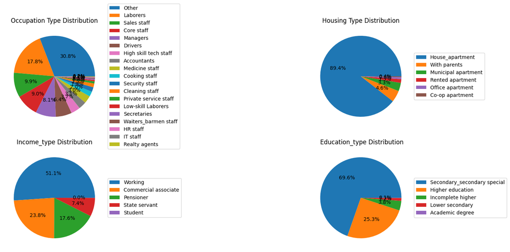

```python
figure , axis = plt.subplots(2,2,figsize=(20,8))
occupation_counts = credit_data['Occupation_type'].value_counts()
axis[0,0].pie(occupation_counts, autopct='%1.1f%%')
axis[0,0].set_title('Occupation Type Distribution')
axis[0,0].legend(occupation_counts.index, loc='center left', bbox_to_anchor=(1, 0.5))


housing_counts = credit_data['Housing_type'].value_counts()
axis[0,1].pie(housing_counts, autopct='%1.1f%%')
axis[0,1].set_title('Housing Type Distribution')
axis[0,1].legend(housing_counts.index, loc='center left', bbox_to_anchor=(1, 0.5))

Income_type_counts = credit_data['Income_type'].value_counts()
axis[1,0].pie(Income_type_counts, autopct='%1.1f%%')
axis[1,0].set_title('Income_type Distribution')
axis[1,0].legend(Income_type_counts.index, loc='center left', bbox_to_anchor=(1, 0.5))

Education_type_counts = credit_data['Education_type'].value_counts()
axis[1,1].pie(Education_type_counts, autopct='%1.1f%%')
axis[1,1].set_title(' Education_type Distribution')
axis[1,1].legend(Education_type_counts.index, loc='center left', bbox_to_anchor=(1, 0.5))

plt.show()
```

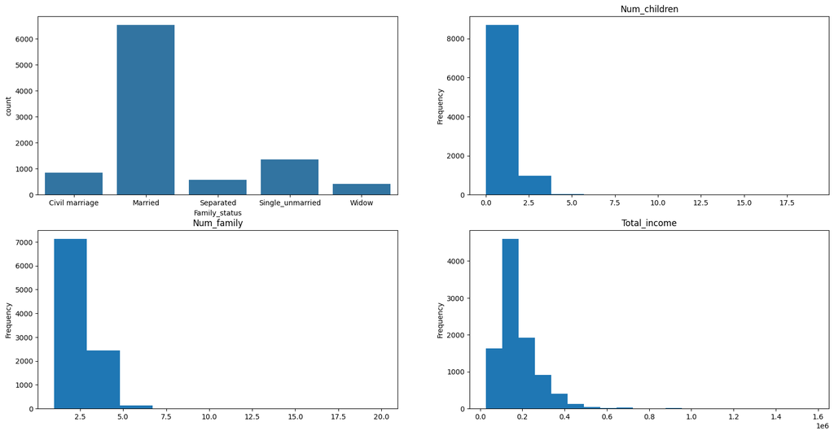

```python
figure , axis = plt.subplots(2,2,figsize=(20,10))
sns.countplot(x="Family_status",data=credit_data,ax=axis[0,0])
credit_data['Num_children'].plot(kind='hist', title='Num_children', ax=axis[0,1])
credit_data['Num_family'].plot(kind='hist', title='Num_family', ax=axis[1,0])
credit_data['Total_income'].plot(kind='hist', bins=20, title='Total_income', ax=axis[1,1])

plt.show()
```

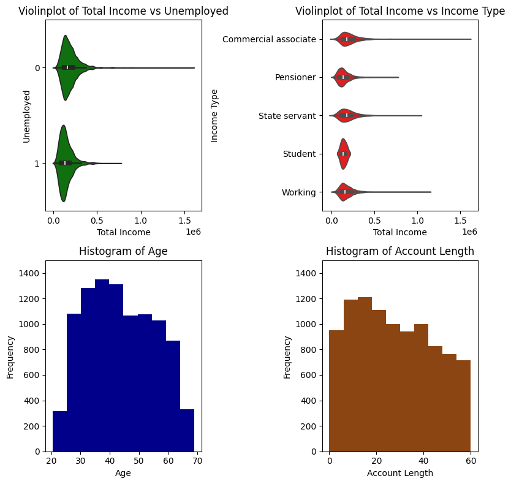

```python
figure, axis =plt.subplots(2,2,figsize=(8,8))

sns.violinplot(y=credit_data['Unemployed'],x=credit_data['Total_income'],ax=axis[0,0],color="green")
axis[0,0].set_xlabel("Total Income")
axis[0,0].set_ylabel("Unemployed")
axis[0,0].set_title("Violinplot of Total Income vs Unemployed")


sns.violinplot(y=credit_data['Income_type'],x=credit_data['Total_income'],ax=axis[0,1],color="red")
axis[0,1].set_xlabel("Total Income")
axis[0,1].set_ylabel("Income Type")
axis[0,1].set_title("Violinplot of Total Income vs Income Type")

axis[1,0].hist(credit_data["Age"],color="darkblue")
axis[1,0].set_xlabel("Age")
axis[1,0].set_ylabel("Frequency")
axis[1,0].set_title("Histogram of Age")
axis[1,0].set_ylim([0,1500])

axis[1,1].hist(credit_data["Account_length"],color="saddlebrown")
axis[1,1].set_xlabel("Account Length")
axis[1,1].set_ylabel("Frequency")
axis[1,1].set_title("Histogram of Account Length")
axis[1,1].set_ylim([0,1500])

plt.tight_layout()
plt.show()
```

Balancing the data

```python
#--balancing the data
credit_data.shape
credit_data['Target'].value_counts()
```

| Target | count |
| --- | --- |
| 0 | 8426 |
| 1 | 1283 |

**dtype:** int64

```python
X=np.array(credit_data.drop(columns=['Target']))
y=credit_data['Target']
smote_nc=SMOTENC([0,1,2,3,4,5,6,13,14,15,16,17],random_state=45)
df=smote_nc.fit_resample(X,y)
credit_data_bal=pd.DataFrame(df[0])
credit_data_bal['Target']=df[1]
credit_data_bal.columns=credit_data.columns
credit_data_bal['Target'].value_counts()
```

| Target | count |
| --- | --- |
| 0 | 8426 |
| 1 | 8426 |

**dtype:** int64

```python
#--converting in suitable format
for i in credit_data_bal.columns[[0,1,2,3,4,5,6,13,14,15,16,17,18]]:
  credit_data_bal[i]=pd.Categorical(credit_data_bal[i])
for i in credit_data_bal.columns[[7,8,9,10,11,12]]:
  credit_data_bal[i]=pd.to_numeric(credit_data_bal[i])
for i in credit_data_bal.columns[[7,8,9]]:
  credit_data_bal[i]=np.floor(credit_data_bal[i]).astype(int)
credit_data_bal.info()
```

```
<class 'pandas.core.frame.DataFrame'>
RangeIndex: 16852 entries, 0 to 16851
Data columns (total 19 columns):
 #   Column           Non-Null Count  Dtype
---  ------           --------------  -----
 0   Gender           16852 non-null  category
 1   Own_car          16852 non-null  category
 2   Own_property     16852 non-null  category
 3   Work_phone       16852 non-null  category
 4   Phone            16852 non-null  category
 5   Email            16852 non-null  category
 6   Unemployed       16852 non-null  category
 7   Num_children     16852 non-null  int64
 8   Num_family       16852 non-null  int64
 9   Account_length   16852 non-null  int64
 10  Total_income     16852 non-null  float64
 11  Age              16852 non-null  float64
 12  Years_employed   16852 non-null  float64
 13  Income_type      16852 non-null  category
 14  Education_type   16852 non-null  category
 15  Family_status    16852 non-null  category
 16  Housing_type     16852 non-null  category
 17  Occupation_type  16852 non-null  category
 18  Target           16852 non-null  category
dtypes: category(13), float64(3), int64(3)
memory usage: 1006.5 KB
```

```python
#--Scaling the neumerical variables and using OneHotEncoding for categorical variables
std=StandardScaler()
credit_data_bal_encoded=pd.get_dummies(credit_data_bal,columns=credit_data_bal.columns[[0,1,2,3,4,5,6,13,14,15,16,17]],drop_first=True)
credit_data_bal_encoded[credit_data_bal_encoded.columns[[0,1,2,3,4,5]]]=std.fit_transform(credit_data_bal_encoded[credit_data_bal_encoded.columns[[0,1,2,3,4,5]]])

for i in credit_data_bal_encoded.columns[np.arange(7,49)]:
  credit_data_bal_encoded[i]=credit_data_bal_encoded[i].astype(int)

credit_data_bal_encoded['Target']=credit_data_bal_encoded['Target'].astype(float)
```

### Model Building

```python
#--creating train-test data
X=credit_data_bal_encoded.drop(columns=['Target'])
y=credit_data_bal_encoded['Target']
X_train,X_test,y_train,y_test=train_test_split(X,y,test_size=0.2)
```

#### Logistic regression

```python
model1=LogisticRegression(max_iter=1000)
model1.fit(X_train,y_train)
```

```
LogisticRegression(max_iter=1000)
```

Checking accuracy metric on Test data

```python
pred1=model1.predict(X_test)
accuracy = accuracy_score(y_test, pred1)
f1 = f1_score(y_test, pred1)
print(f"Accuracy: {accuracy:.2f}")
print(f"F1 score: {f1:.2f}")
```

```
Accuracy: 0.72
F1 score: 0.72
```

ROC Curve and AUC score

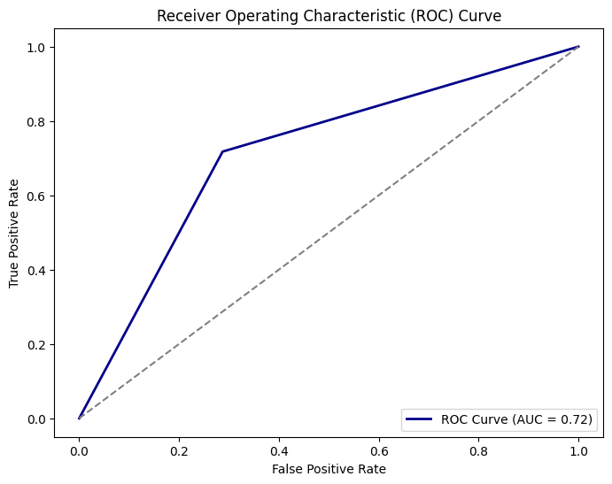

```python
roc_auc = roc_auc_score(y_test, pred1)
fpr, tpr, thresholds = roc_curve(y_test, pred1)
plt.figure(figsize=(8, 6))
plt.plot(fpr, tpr, color='darkblue', lw=2, label=f'ROC Curve (AUC = {roc_auc:.2f})')
plt.plot([0, 1], [0, 1], color='gray', linestyle='--')
plt.xlabel('False Positive Rate')
plt.ylabel('True Positive Rate')
plt.title('Receiver Operating Characteristic (ROC) Curve')
plt.legend(loc='lower right')
plt.show()
```

#### Artificial Neural Network Model

```python
model2 = Sequential()

model2.add(Dense(512,input_dim=X_train.shape[1],activation='relu',kernel_initializer='he_normal'))
model2.add(Dropout(0.2))

model2.add(Dense(512,activation='relu',kernel_initializer='he_normal'))
model2.add(Dropout(0.2))

model2.add(Dense(256,activation='relu',kernel_initializer='he_normal'))

model2.add(Dense(64,activation='relu',kernel_initializer='he_normal'))

model2.add(Dense(1, activation='sigmoid'))

model2.compile(optimizer=Adam(learning_rate =0.001),loss='binary_crossentropy',metrics=['accuracy'])

early_stopping = EarlyStopping(monitor='val_accuracy',patience=10,restore_best_weights=True)

model2.summary()
```

```
Model: "sequential"
```

```
┏━━━━━━━━━━━━━━━━━━━━━━━━━━━━━━━━━━━━━━┳━━━━━━━━━━━━━━━━━━━━━━━━━━━━━┳━━━━━━━━━━━━━━━━━┓
┃ Layer (type)                         ┃ Output Shape                ┃         Param # ┃
┡━━━━━━━━━━━━━━━━━━━━━━━━━━━━━━━━━━━━━━╇━━━━━━━━━━━━━━━━━━━━━━━━━━━━━╇━━━━━━━━━━━━━━━━━┩
│ dense (Dense)                        │ (None, 512)                 │          25,088 │
├──────────────────────────────────────┼─────────────────────────────┼─────────────────┤
│ dropout (Dropout)                    │ (None, 512)                 │               0 │
├──────────────────────────────────────┼─────────────────────────────┼─────────────────┤
│ dense_1 (Dense)                      │ (None, 512)                 │         262,656 │
├──────────────────────────────────────┼─────────────────────────────┼─────────────────┤
│ dropout_1 (Dropout)                  │ (None, 512)                 │               0 │
├──────────────────────────────────────┼─────────────────────────────┼─────────────────┤
│ dense_2 (Dense)                      │ (None, 256)                 │         131,328 │
├──────────────────────────────────────┼─────────────────────────────┼─────────────────┤
│ dense_3 (Dense)                      │ (None, 64)                  │          16,448 │
├──────────────────────────────────────┼─────────────────────────────┼─────────────────┤
│ dense_4 (Dense)                      │ (None, 1)                   │              65 │
└──────────────────────────────────────┴─────────────────────────────┴─────────────────┘
```

```
 Total params: 435,585 (1.66 MB)
```

```
 Trainable params: 435,585 (1.66 MB)
```

```
 Non-trainable params: 0 (0.00 B)
```

```python
history = model2.fit(x= X_train, y= y_train, validation_data=(X_test,y_test), batch_size= 256, epochs=1000, verbose=0,
          callbacks=[early_stopping])
```

Predicting accuracy for ANN model

```python
pred2= model2.predict(X_test)
pred2_binary = (pred2 > 0.5).astype(int)  # Convert probabilities to binary predictions (0 or 1)
accuracy = accuracy_score(y_test, pred2_binary)
f1 =f1_score(y_test, pred2_binary)
print(f"Accuracy: {accuracy:.2f}")
display(HTML(f"<h3>Model Accuracy: {np.round(accuracy,2)}</h3>"))
print(f"F1 Score: {f1:.2f}")
display(HTML(f"<h3>Model F1 score: {np.round(f1,2)}</h3>"))
```

```
106/106 ━━━━━━━━━━━━━━━━━━━━ 0s 2ms/step
Accuracy: 0.83
```

Model Accuracy: 0.83

```
F1 Score: 0.83
```

Model F1 score: 0.83

ROC curve and AUC score

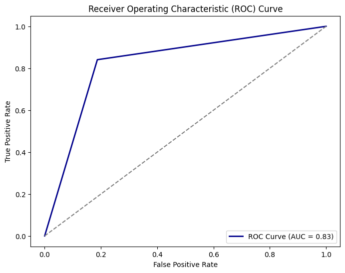

```python
roc_auc = roc_auc_score(y_test,pred2_binary)
fpr ,tpr, threshold = roc_curve(y_test,pred2_binary)
plt.figure(figsize=(8, 6))
plt.plot(fpr, tpr, color='darkblue', lw=2, label=f'ROC Curve (AUC = {roc_auc:.2f})')
plt.plot([0, 1], [0, 1], color='gray', linestyle='--')
plt.xlabel('False Positive Rate')
plt.ylabel('True Positive Rate')
plt.title('Receiver Operating Characteristic (ROC) Curve')
plt.legend(loc='lower right')
plt.show()
```

#### Function for predicting risk using the ANN model

```python
new_data=pd.DataFrame(0,index=[0],columns=X_train.columns)
def predict_credit_risk(
    Gender, Work_phone, Own_car, Own_property,Phone, Email, Unemployed, Num_children, Num_family,
    Total_income, Age, Years_employed, Income_type, Account_length, Housing_type,
    Occupation_type, Education_type,Family_status
    ):
    # Gender
    if Gender == "Male":
        new_data.iloc[:,6] = 1

    # Work phone
    if Work_phone == "Yes":
        new_data.iloc[:,9] = 1

    # Own car
    if Own_car == "Yes":
        new_data.iloc[:,7] = 1

    # Own_property
    if Own_property == "Yes":
        new_data.iloc[:,8] = 1
    # Phone
    if Phone == "Yes":
        new_data.iloc[:,10] = 1

    # Email
    if Email == "Yes":
         new_data.iloc[:,11] = 1

    # Unemployed
    if Unemployed == "Yes":
        new_data.iloc[:,12] = 1

    # Income type
    if Income_type == "Working":
        new_data.iloc[:,16] = 1
    elif Income_type == "Pensioner":
        new_data.iloc[:,13] = 1
    elif Income_type == "State servant":
        new_data.iloc[:,14] = 1
    elif Income_type == "Student":
        new_data.iloc[:,15] = 1

    # Education type
    if Education_type == "Higher education":
        new_data.iloc[:,17] = 1
    elif Education_type == "Secondary_secondary special":
        new_data.iloc[:,20] = 1
    elif Education_type == "Incomplete higher":
        new_data.iloc[:,18] = 1
    elif Education_type == "Lower secondary":
        new_data.iloc[:,19] = 1

    # Family status
    if Family_status == "Married":
        new_data.iloc[:,21] = 1
    elif Family_status == "Separated":
        new_data.iloc[:,22] = 1
    elif Family_status == "Single_unmarried":
        new_data.iloc[:,23] = 1
    elif Family_status == "Widow":
        new_data.iloc[:,24] = 1

    # Housing type
    if Housing_type == "Rented apartment":
        new_data.iloc[:,28] = 1
    elif Housing_type == "With parents":
        new_data.iloc[:,29] = 1
    elif Housing_type == "Municipal apartment":
        new_data.iloc[:,26] = 1
    elif Housing_type == "House_apartment":
        new_data.iloc[:,25] = 1
    elif Housing_type == "Office apartment":
        new_data.iloc[:,27] = 1

    # Occupation type
    if Occupation_type == "Laborers":
        new_data.iloc[:,37] = 1
    elif Occupation_type == "Core staff":
        new_data.iloc[:,32] = 1
    elif Occupation_type == "Managers":
        new_data.iloc[:,39] = 1
    elif Occupation_type == "Sales staff":
        new_data.iloc[:,44] = 1
    elif Occupation_type == "Drivers":
        new_data.iloc[:,33] = 1
    elif Occupation_type == "High skill tech staff":
        new_data.iloc[:,35] = 1
    elif Occupation_type == "Medicine staff":
        new_data.iloc[:,40] = 1
    elif Occupation_type == "IT staff":
        new_data.iloc[:,36] = 1
    elif Occupation_type == "Cleaning staff":
        new_data.iloc[:,30] = 1
    elif Occupation_type == "Cooking staff":
        new_data.iloc[:,31] = 1
    elif Occupation_type == "HR staff":
        new_data.iloc[:,34] = 1
    elif Occupation_type == "Low-skill Laborers":
        new_data.iloc[:,38] = 1
    elif Occupation_type == "Realty agents":
        new_data.iloc[:,43] = 1
    elif Occupation_type == "Security staff":
        new_data.iloc[:,46] = 1
    elif Occupation_type == "Waiters_barmen staff":
        new_data.iloc[:,47] = 1
    elif Occupation_type == "Other":
        new_data.iloc[:,41] = 1
    elif Occupation_type == "Private service staff":
        new_data.iloc[:,42] = 1
    elif Occupation_type == "Secretaries":
        new_data.iloc[:,45] = 1


    # Normalize numeric inputs
    new_data.iloc[:,0] = (Num_children - X_train['Num_children'].describe()[1]) / X_train['Num_children'].describe()[2]
    new_data.iloc[:,1] = (Num_family - X_train['Num_family'].describe()[1]) / X_train['Num_family'].describe()[2]
    new_data.iloc[:,2] = (Account_length - X_train['Account_length'].describe()[1]) / X_train['Account_length'].describe()[2]
    new_data.iloc[:,3] = (((Total_income)/11.75) - X_train['Total_income'].describe()[1]) / X_train['Total_income'].describe()[2]
    new_data.iloc[:,4] = (Age - X_train['Age'].describe()[1]) / X_train['Age'].describe()[2]
    new_data.iloc[:,5] = (Years_employed - X_train['Years_employed'].describe()[1]) / X_train['Years_employed'].describe()[2]

     # Predict credit risk
    pred2 = model2.predict(new_data)

    # Convert prediction to binary class
    prediction = (pred2 > 0.5).astype(int)

    if prediction == 1:
        prediction_final = "High "
    else:
        prediction_final = "Low "

    return prediction_final
```

Let us try to predict on a given input

```python
pred_datapoint=predict_credit_risk(
    Gender="Male",
    Work_phone="Yes",
    Own_car="Yes", Phone="Yes",
    Email="Yes",
    Unemployed="No",
    Num_children=0,
    Num_family=4,
    Total_income=200000,
    Age=22, Years_employed=1,
    Income_type="Working",
    Account_length=12,
    Housing_type="With parents",
    Occupation_type="IT staff",
    Education_type="Higher education",
    Family_status="Single_unmarried",
    Own_property="Yes")
display(HTML(f"<h3>Credit card user risk : {pred_datapoint}</h3>"))
```

```
1/1 ━━━━━━━━━━━━━━━━━━━━ 0s 25ms/step
```

Credit card user risk : High

# Conclusion

## Summmary Findings

- **We have a clear higher accuracy in ANN model than Logistic model.**
- **We have a clear higher F1 score in ANN model than Logistic model.**
- **We have a clear higher ROC AUC in ANN model than Logistic model.**

Higher Accuracy: The ANN model has demonstrated superior accuracy compared to the Logistic Regression model. This indicates that the ANN model is more proficient at correctly classifying both the default and non-default classes overall.

Higher F1 Score: The ANN model's higher F1 score suggests it performs better in balancing precision and recall, which is crucial in imbalanced datasets where one class (e.g., high risk) may be less frequent. This indicates that the ANN model is more effective at minimizing both false positives and false negatives, which is especially important in credit card risk prediction where the cost of misclassification can be high.

Higher ROC AUC: The ANN model also exhibits a higher ROC AUC score, reflecting its enhanced ability to discriminate between the high risk and low risk classes across different classification thresholds. A higher ROC AUC confirms that the ANN model is more effective at distinguishing between high-risk and low-risk customers.

## Discussion

**Model Complexity and Capability:**

- ANN Advantages: The superior performance of the ANN model can be attributed to its ability to capture complex, non-linear relationships within the data. ANNs are designed to learn intricate patterns through their multiple layers and neurons, which makes them more flexible and capable of modeling complex interactions between features. Logistic Regression Limitations: Logistic Regression, while simpler and more interpretable, is inherently limited to modeling linear relationships. It may not capture the complexities and non-linearities in the data as effectively as an ANN.

**Interpretability vs. Performance:**

- ANN Trade-offs: Despite its higher performance metrics, the ANN model comes with increased complexity, which can make it harder to interpret. This "black box" nature of ANNs can be a drawback in contexts where model interpretability is crucial for regulatory or decision-making purposes. Logistic Regression Strengths: Logistic Regression's main advantage lies in its transparency and ease of interpretation. It provides clear insights into how individual features affect the probability of default, which can be valuable for understanding and explaining model predictions.

## Recommendations

- **For High Accuracy and Complex Data:** If your priority is achieving the highest possible accuracy and your data exhibits complex patterns, the ANN model is the better option. Ensure that you have the computational resources and tools for model training and deployment.
- **For Interpretability and Simplicity:** If interpretability, ease of implementation, and computational efficiency are more important, Logistic Regression remains a viable choice. It provides valuable insights into the model’s decision-making process, which can be crucial in a financial context.

```python
!jupyter nbconvert --execute --to html /content/drive/MyDrive/credit_approval/credit_card_risk.ipynb
```

[output not shown]